# Battery Consumption: Comparison of Software Measures

Corey Dow-Hygelund, Mozilla Data Science

The current experimentation process utilizes *Intel Power Gadget* (IPG) to measure battery consumption using `Processor Energy` as a proxy. This is due to *Intel Power Gadget* having sufficient resolution and being cross-platform. This analysis is intended to determine the validity of such an proxy, measuring battery usage utilizing the Windows specific *Battery Report* in addition to the `psutil` Python library. A range of websites are tested to determine influential factors, such as GPU usage in video.

# Summary

- IPG is an effective proxy for measure battery usage.
- However, there are effects related battery level, that can influence the relationship by up to ~15%.
- This is observed for both `psutil` and Battery Report
- As the battery level decreases, the measured powered usage relates to higher battery usage.
- Battery Report can measure lower battery levels than `psutil`.

# Description

A total of 14 runs were performed across two days. Each run was composed of navigating to 22 different urls in the following fashion:

1. navigate to `about:blank`
2. sleep for 30 seconds
3. navigate to desired url
4. sleep for 60 seconds

The order of 22 urls were shuffled between runs.

At the end of the run, the battery level was checked by `psutil`. If it fell below 40%, the experiment was paused, while the Tp100 smartplug was turned on to charge the laptop. Once it reached 98%, the experiment was resumed.

# Windows Battery Report and IPG

Examine the Windows Battery Report versus IPG reported energy usage across the run.

## Single Run

Plotting a single run, in addition to a linear model fit.

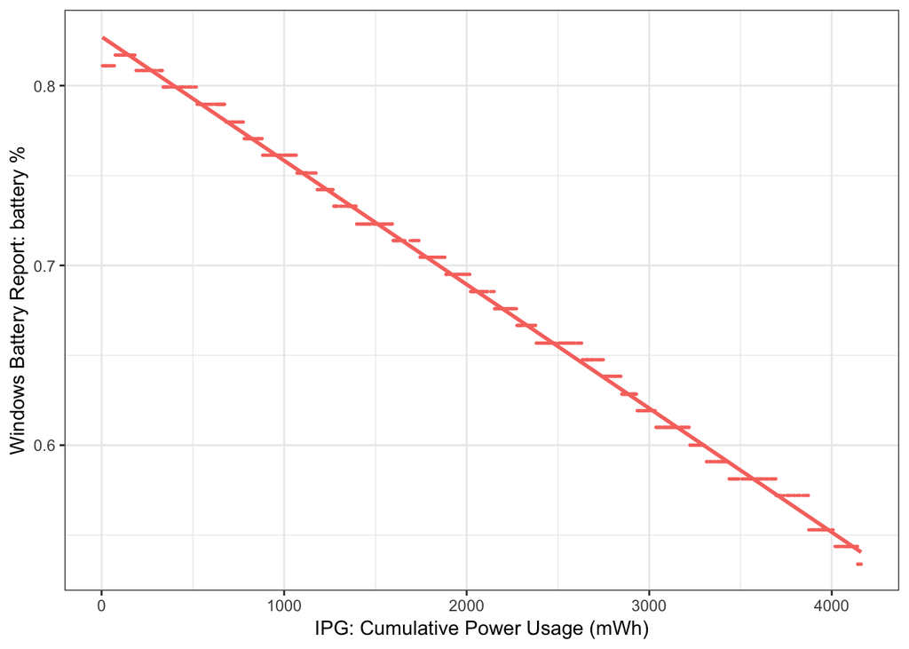

The poor resolution of battery report is evident. Fortunately, IPG measured power usage linearly maps to battery consumption.

## All Runs

Plotting all runs to see if there is any change of the observation above.

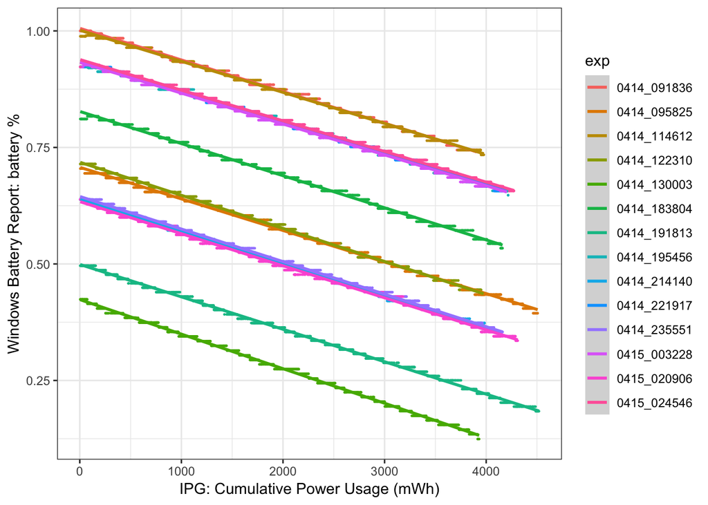

## Relationship

Calculating the slope of the relationship for each run:

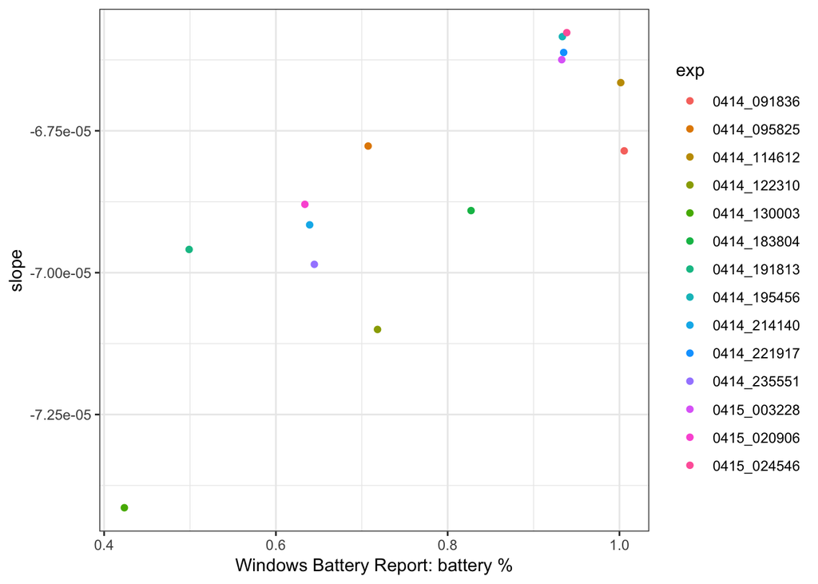

There exists a trend for stronger for greater battery drain to IPG measured power usage as the battery level decreases. This difference across battery level is non-negligable, but small, being around 13%.

# psutil and IPG

The following is an identical methodology to the above, swapping the `psutil` measure of battery level with Battery Report.

## Single Run

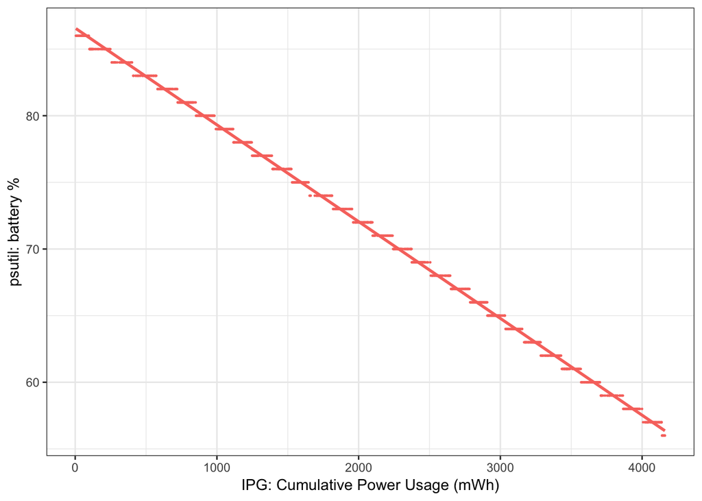

## All Runs

Plotting all runs to see if there is any change of the observation above.

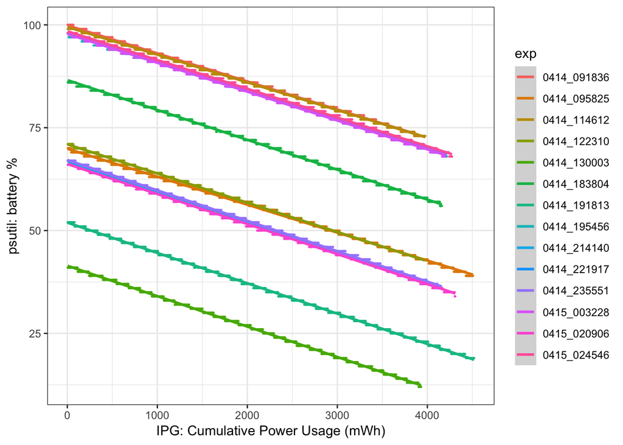

## Relationship

Calculating the slope of the relationship for each run:

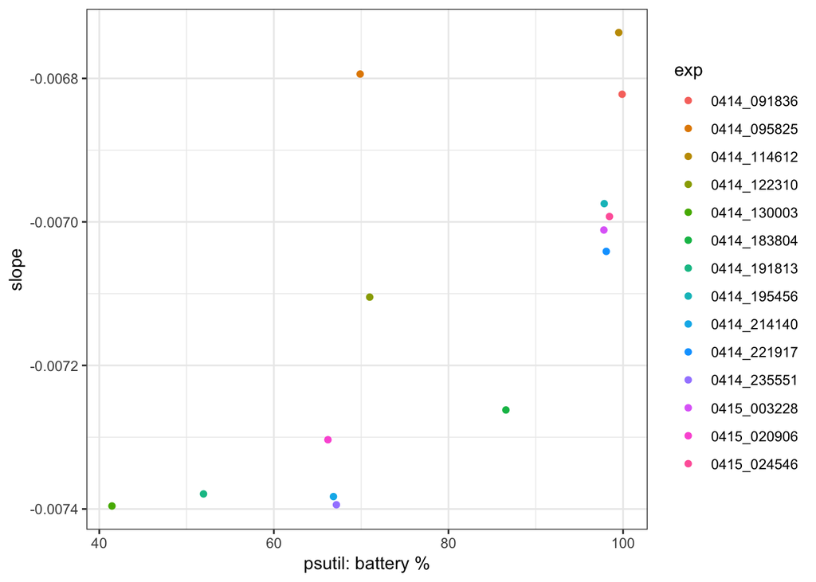

The same trend exists, but appears more non-linear and is somewhat weaker (10%).

# Windows Battery Report and psutil

Plotting the battery level reported by both software measures:

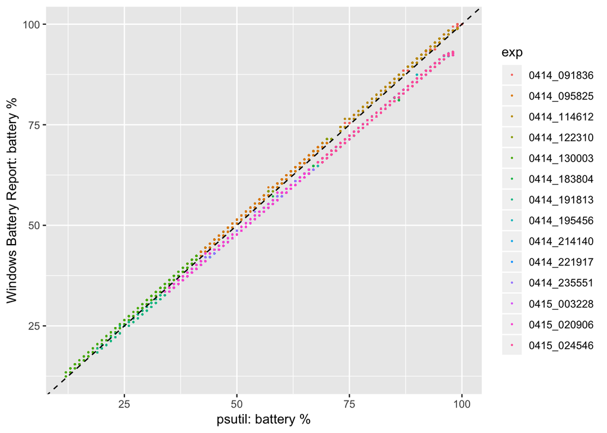

The dotted line represents both measures reporting the same level. For a suite of experiments, Battery report is measuring low with respect to `psutil`.

Fitting a line to the psutil to Battery Report relationship:

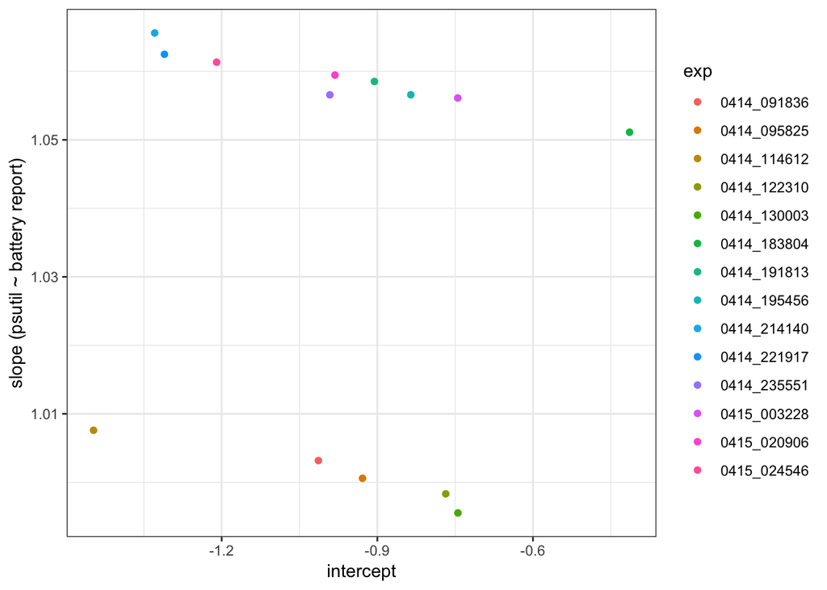

It appears that runs with the discrepancy occur after 04/14 18:00.

**Question**: Can this be replicated to determine a cause?

Table of Nightly build for each experiment:

|  | application_buildid | platform_buildid | exp |
| --- | --- | --- | --- |
| 1 | 20190413214623 | 20190413214623 | 0414_091836 |
| 4 | 20190413214623 | 20190413214623 | 0414_095502 |
| 7 | 20190414095735 | 20190414095735 | 0414_095825 |
| 2 | 20190414095735 | 20190414095735 | 0414_114612 |
| 5 | 20190414095735 | 20190414095735 | 0414_122310 |
| 8 | 20190414095735 | 20190414095735 | 0414_130003 |
| 3 | 20190414095735 | 20190414095735 | 0414_183804 |
| 6 | 20190414095735 | 20190414095735 | 0414_191445 |
| 9 | 20190414214746 | 20190414214746 | 0414_191813 |
| 10 | 20190414214746 | 20190414214746 | 0414_195456 |
| 11 | 20190414214746 | 20190414214746 | 0414_214140 |
| 12 | 20190414214746 | 20190414214746 | 0414_221917 |
| 13 | 20190414214746 | 20190414214746 | 0414_235551 |
| 14 | 20190414214746 | 20190414214746 | 0415_003228 |
| 15 | 20190414214746 | 20190414214746 | 0415_020906 |
| 16 | 20190414214746 | 20190414214746 | 0415_024546 |

It doesn’t appear to be an issue with the Firefox build.